# Going Back To ‘Chopping’ Tables

CPLN-503 Modeling Geographic Objects

Author

Jamaal Green

Published

September 26, 2024

# Introduction

As you all are working through your mini-projects I figured it would be useful to revisit/review some approaches for what I affectionately call “chopping tables”. This is a brief/high level overview of some **dplyr** commands, but mainly it is to think about how we attack working with and manipulating tabular data. In short, if we have an idea of what the *shape* of our table *should* look like, then we can have an idea of what our approach should be, whether it’s in R, Excel or ArcPro.

Ideally, you can use this document alongside the slides we went over earlier on tables as a way to guide you. As such, I won’t spend too much time going over certain things I discuss in the slides. Check those resources and the resources in the syllabus for even more detail.

# Our Data

```r
if(!require(pacman)){install.packages("pacman"); library(pacman)}
p_load(sf, tmap, tigris, tidyverse, RColorBrewer)
options(scipen = 999)


violations <- read_csv("https://phl.carto.com/api/v2/sql?&filename=violations&format=csv&skipfields=cartodb_id,the_geom,the_geom_webmercator&q=SELECT%20*,%20ST_Y(the_geom)%20AS%20lat,%20ST_X(the_geom)%20AS%20lng%20FROM%20violations%20WHERE%20violationdate%20%3E=%20%272019-01-01%27")
```

For importing our data I’ll load up the **tidyverse** and **sf, tmap** and **tigris** (we use **tigris** to grab [Census Tigerline](https://www.census.gov/geographies/mapping-files/time-series/geo/tiger-line-file.html) files directly) and the **RColorBrewer** packages. This brief overview/review will go over some top line table operations we can use to get some summary calculations, do some pretty basic geoprocessing and mapping to show how we can make our tables sing or offer us better information.

# Choppin’ Tables

Okay…let’s start. A basic question we want to always ask ourselves when we’re working with our tables is what is our unit of analysis? In other words, what is the unit we actually care about in terms of summaries and how is that unit represented in the table? What is the unit of analysis for our `violations` table? One way to think of the your unit of analysis is what configuration of your variables that makes each *row* distinct (e.g. no duplications?). Depending on the type of data you have this may be single column (such as a true primary key in a database) or it may be a combination of columns (such as a table with FirstName, LastName, Birthday as a potential ID across multiple columns). For this table the unit of analysis of our table *should* be the *casenumber*. But is that the case? Let’s take a quick look.

## Checking for duplicates

There are many ways to check for duplicates. The approach I’m offering here uses **dplyr**, but there are base-r, Excel or any number of approaches here. What’s important is you understand why this matters and the logic I’m taking.

```r
violations_dupes <- violations %>%
  group_by(casenumber) %>%
  tally() %>%
  arrange(desc(n)) %>%
  head()
```

If you view your `violations_dupes` dataframe you should see 6 ticket numbers and a column “n” which is the count of the number of times those ticket numbers appear in the dataframe. Let’s break down our call here.

1. I feed `violations` into a `group_by(casenumber)` because we want to know whether our tickets are duplicated, and then pipe into a `tally()` which will give us a count of each instance of that ticket number found in our dataframe.
2. Because we want to be sure we can see cases that are actual duplicates without looking 400k+ rows we will arrange our output by `n` (the number of times a ticket number is found in the dataframe) in a *descending* fashion
3. Finally, we take the top-6 results using the `head()` function.

Note the 3 basic steps here, calculate the number of instances of our tickets, arrange those counts in descending order and then give me the top 6 results. What you should see if this table has duplicates! In fact, each `casenumber` can be repeated multiple times. You can confirm this by exploring your dataframe in RStudio. Click on it in your local environment, sort the `casenumber` column and look at the values.

Top 6 Case Number Duplicate Rows

| casenumber | n |
| --- | --- |
| CF-2023-093417 | 89 |
| CF-2023-042991 | 56 |
| CF-2022-039774 | 46 |
| CF-2023-066239 | 46 |
| CF-2023-049025 | 43 |
| CF-2024-074147 | 42 |

And what do we see? There are a LOT of duplicate rows in our table. So this let’s us know that the `casenumber` is *not* our unique identifier for this table. This isn’t necessarily fatal for our analysis, but it does mean we need to think a bit closer how we want to summarize our violations. To get a better sense of what’s going on let’s pull out one of the duplicated ticket numbers to see what is, or is not, unique about it.

1. Let’s subset our rows so we only keep ticket “CF-2023-010908” (what command is that?)
2. Keep the columns we think are most important for readability
3. Pull only the top 6 results to save space

```r
viol_check <- violations %>%
  filter(casenumber == "CF-2023-010908") %>%
  select(casenumber, casetype:violationnumber, violationcode) %>%
  head()
```

Case CF-2023-010908 Cut Down Table

| casenumber | casetype | casestatus | caseresponsibility | caseprioritydesc | violationnumber | violationcode |
| --- | --- | --- | --- | --- | --- | --- |
| CF-2023-010908 | NOTICE OF VIOLATION | IN VIOLATION - COURT | FIRE SAFETY INVESTIGATOR | STANDARD | VI-2023-008621 | F-907.8.5 |
| CF-2023-010908 | NOTICE OF VIOLATION | IN VIOLATION - COURT | FIRE SAFETY INVESTIGATOR | STANDARD | VI-2023-008622 | F-913.5 |
| CF-2023-010908 | NOTICE OF VIOLATION | IN VIOLATION - COURT | FIRE SAFETY INVESTIGATOR | STANDARD | VI-2023-008623 | F-901.6.4 |
| CF-2023-010908 | NOTICE OF VIOLATION | IN VIOLATION - COURT | FIRE SAFETY INVESTIGATOR | STANDARD | VI-2023-008634 | F-607.3.3.3 |
| CF-2023-010908 | NOTICE OF VIOLATION | IN VIOLATION - COURT | FIRE SAFETY INVESTIGATOR | STANDARD | VI-2023-008635 | F-1104.5 |
| CF-2023-010908 | NOTICE OF VIOLATION | IN VIOLATION - COURT | FIRE SAFETY INVESTIGATOR | STANDARD | VI-2023-008636 | F-1104.5 |

Okay, there may be something new here for folks so let’s break down what we did.

1. We feed our `violations` dataframe into a `filter()` so we can subset our rows based on our case number of interest
2. Then because we want to keep only certain rows we pipe into a `select()` and note that we can name our columns *without* having to quote them in this function and that I was able to grab a *range* of columns using the `:` to grab those specific columns and all those in between (this is a really handy shortcut that **dplyr** gives us)

So, after closer inspection it seems like the true unique ID is the `violationnumber` column. So, let’s check for dupes there, what do you see? I’ll let you reproduce the duplication step again on your own. I will say to return to *all* columns this time and check one of the duplicate rows.

Check the code underneath here for one way of doing this. But experiment with an approach first.

```r
viol_check2 <- violations %>%
  group_by(violationnumber) %>%
  tally() %>%
  filter( n > 1)


dupe_rows <- as_vector(viol_check2$violationnumber)

viol_check3 <- violations %>%
  filter(violationnumber %in% c(dupe_rows))
```

Let’s break it down:

1. We now have our pretty standard `group_by()` and `tally()` lines, but this time we add an additional `filter()` call to keep only our duplicate rows
2. our `viol_check2` dataframe now has two columns: one for violation number and one for the count of the rows for each violation number
3. But we want to pick out those rows from our larger dataframe so we can see what’s going on…how do we solve this?
   1. We create a new *vector* called `dupe_rows` and we use the `as_vector()` function from the **purrr** package (another **tidyverse** package) on the violation number column from our `viol_check2` dataframe
   2. Take a look at your local environment so you can what `dupe_rows` is
4. Finally, we create a new dataframe, `viol_check3`, where we `filter()` our original violations table but we keep only the `dupe_rows` violations from the `violationnumber` column using the `%in%` operator we’ve discussed before

What is it about these rows that make them duplicates? It’s unclear! There are a few sources of duplication here. Let’s investigate a bit…we will pull out a specific address:

`3220 N 16TH ST`

How could we pull this address out (remember, we’re subsetting a *row*)? What seems to be the issue?

Chasing down dupes!

| casenumber | violationnumber | opa_owner | opa_account_num |
| --- | --- | --- | --- |
| CF-2020-014920 | VI-2020-004888 | NA | 776000001 |
| CF-2020-014920 | VI-2020-004888 | MT SINAI HOLY CHURCH, OF AMERICA | 776340000 |
| CF-2020-014920 | VI-2020-004889 | NA | 776000001 |
| CF-2020-014920 | VI-2020-004889 | MT SINAI HOLY CHURCH, OF AMERICA | 776340000 |
| CF-2020-014920 | VI-2020-004890 | NA | 776000001 |
| CF-2020-014920 | VI-2020-004890 | MT SINAI HOLY CHURCH, OF AMERICA | 776340000 |
| CF-2020-014920 | VI-2020-004891 | NA | 776000001 |
| CF-2020-014920 | VI-2020-004891 | MT SINAI HOLY CHURCH, OF AMERICA | 776340000 |
| CF-2020-014920 | VI-2020-004892 | NA | 776000001 |
| CF-2020-014920 | VI-2020-004892 | MT SINAI HOLY CHURCH, OF AMERICA | 776340000 |

Ah! It looks owner information is the culprit here. This one property has two OPA accounts associated with it, one with an owner’s name and one without! In this case it looks like we have a situation where we have found true duplicates, and it seems to be linked to some weirdness in either OPA’s documentation or the good folks at Licenses and Inspections (L&I) made some kind of transcription error. The source of this duplication is not important to us right now, but if you were working for the city as an analyst or planner that needed to track or make use of the violations dataset, then it may be worth it to bring it up (data quality matters, folks).

## De-duping the table

Okay, let’s drop these dupes. In this case, we have a pretty clear duplication that has a pretty straightforward solution. Let’s a take a look.

```r
violations <- violations %>%
  distinct(violationnumber, .keep_all = TRUE)
```

This should look relatively straightforward. We use the `distinct()` function from **dplyr,** we tell it which column we want distinct *rows* for, and because we want to keep all of our other information we make the `.keep_all =` function equal to `TRUE`. If we did not tell the function we wanted to keep all of our columns it would return *only* the distinct ticket numbers. If you’re curious if it worked, then take a look at our example address from above and see what comes up now in our dataframe.

## Frequency of Violations

Okay. We should have a de-duped table, now we can do some work. Let’s start with the frequency of different kinds of violations.

```r
violation_ct <- violations %>%
  count(violationcodetitle) %>%
  arrange(desc(n)) %>%
  slice_head(n = 10)
```

Let’s break this down. I introduce a couple of new functions here, but if you run the command you should see what we’re doing.

1. Take our `violations()` dataframe and pipe it into our `count()` function. `count()` is another convenience function in **dplyr** that combines `group_by()` and `tally()` in one. In other word this is equivalent to explicitly grouping on the violation description and then piping that into tally.
2. We take our counts and arrange them in descending order by their frequency
3. We get the top 10 results by using the `slice_head()` function from **dplyr**

The results should look something like this for you.

Top 10 Violations

| violationcodetitle | n |
| --- | --- |
| EXTERIOR AREA WEEDS | 78530 |
| RUBBISH & GARBAGE | 41965 |
| CLIP VIOLATION NOTICE | 27143 |
| VACANT STRUCTURE & LAND | 23115 |
| VACANT STRUCTURE LICENSE | 15895 |
| HIGH WEEDS-CUT | 13290 |
| EXTERIOR AREA SANITATION | 12676 |
| UNSAFE STRUCTURE | 9850 |
| INTERIOR SURFACES | 8781 |
| RENTAL LICENSE- ONE & TWO FAMILY (R3) | 8048 |

# Calculating Some Summary Values

Next, we will calculate some summary values. Because these are primarily categorical variables I will demonstrate a couple of ways to look at frequencies and calculate proportions. Then, finally, we’ll do some summary values by geography by bringing in some census data.

## Violation Status Proportions

Okay, let’s start relatively small. What proportion of violations are closed, open etc? How can we attack this?

1. Get a count of the number of the rows by the case status
2. Divide the the number of rows by the *total* number of observations to get a proportion

```r
case_prop <- violations %>%
  count(casestatus) %>%
  mutate(case_prop = n/sum(n))
```

So, we did something a little different here. We used our `count()` function and then piped that into a `mutate()`, but note our `case_prop` expression. We take the quotient of `n`, or the count of rows, over the `sum(n)` or the total number of instances of `n`! This is a handy way of getting proportions when we’re dealing with frequency tables.

Case Status Proportions

| casestatus | n | case_prop |
| --- | --- | --- |
| CANCELLED | 126 | 0.000 |
| CLOSED | 389346 | 0.730 |
| COMPLIED, BALANCE DUE | 17604 | 0.033 |
| IN VIOLATION | 95202 | 0.178 |
| IN VIOLATION - COURT | 23338 | 0.044 |
| STOP WORK | 11 | 0.000 |
| SVN ISSUED, BALANCE DUE | 7745 | 0.015 |
| UNDER INVESTIGATION | 126 | 0.000 |

## Violation Proportion by Case Status

This is a pretty flexible approach and we can use it for multiple groups. Let’s say we want to see what proportion of cases are still in violation by violation type. Here’s one way we can approach it (let me know if you figure out some different/better ways).

1. Get a count of violations by their violation code and case status
2. Get the sum of violations by the violation code
3. Calculate the proportion of violations by their case status *for their violation code*
4. Grab those rows that are still in violation and have greater than equal to 3,000 violations (to cut down on the large number of rows)

```r
open_viols <- violations %>%
  count(violationcodetitle, casestatus) %>%
  ungroup() %>%
  group_by(violationcodetitle) %>%
  mutate(viol_code_total = sum(n),
         viol_code_prop = n/viol_code_total) %>%
  filter(casestatus == "IN VIOLATION", viol_code_total >= 3000)
```

We make a LOT of steps here so run these lines in smaller chunks if you’re having trouble reading them. But our basic steps were as we outlined above. Note that I added `ungroup()` here. We technically don’t need to add an `ungroup()` as the `count()` function is generally smart enough to not carry our grouping structure, but sometimes we just want to be extra careful and so we tell **dplyr** that remove any groups that may be on our dataframe, then we re-group our dataframe on our `violationcodetitle` column and use `mutate()` to add our new columns of interest. Finally, we throw in our `filter()` commands. These final steps should seem more familiar by now.

| violationcodetitle | casestatus | n | viol_code_total | viol_code_prop |
| --- | --- | --- | --- | --- |
| ARCHITECT/ENGINEER SERVICES | IN VIOLATION | 1595 | 6021 | 0.2649062 |
| CLIP VIOLATION NOTICE | IN VIOLATION | 438 | 27143 | 0.0161368 |
| DOOR AND WINDOW VACANT | IN VIOLATION | 2395 | 4514 | 0.5305716 |
| EXT A-VACANT LOT CLEAN/MAINTAI | IN VIOLATION | 128 | 7617 | 0.0168045 |
| EXTERIOR AREA MOTOR VEHICLE WITHIN THE PROPERTY LINE | IN VIOLATION | 474 | 4134 | 0.1146589 |
| EXTERIOR AREA SANITATION | IN VIOLATION | 2481 | 12676 | 0.1957242 |
| EXTERIOR AREA WEEDS | IN VIOLATION | 7405 | 78530 | 0.0942952 |
| EXTERIOR STRUCTURE ROOF DRAINAGE | IN VIOLATION | 1097 | 3958 | 0.2771602 |
| EXTERIOR STRUCTURE WINDOWS, SKYLIGHTS DOOR FRAMES | IN VIOLATION | 827 | 3017 | 0.2741134 |
| EXTERIOR WALLS | IN VIOLATION | 2099 | 5925 | 0.3542616 |
| HIGH WEEDS-CUT | IN VIOLATION | 205 | 13290 | 0.0154251 |
| INTERIOR SURFACES | IN VIOLATION | 1716 | 8781 | 0.1954219 |
| LITTER ON VACANT LOTS | IN VIOLATION | 4 | 6504 | 0.0006150 |
| NEW USE | IN VIOLATION | 1754 | 5195 | 0.3376323 |
| PERIODIC TESTING | IN VIOLATION | 1737 | 4501 | 0.3859142 |
| RENTAL LICENSE- ONE & TWO FAMILY (R3) | IN VIOLATION | 1096 | 8048 | 0.1361829 |
| ROOF DEFICIENCIES | IN VIOLATION | 1240 | 3509 | 0.3533770 |
| RUBBISH & GARBAGE | IN VIOLATION | 2491 | 41965 | 0.0593590 |
| RUBBISH/GARBAGE EXTERIOR-OWNER | IN VIOLATION | 142 | 7090 | 0.0200282 |
| UNSAFE STRUCTURE | IN VIOLATION | 3009 | 9850 | 0.3054822 |
| VACANT PROPERTIES | IN VIOLATION | 3542 | 6793 | 0.5214191 |
| VACANT STRUCTURE & LAND | IN VIOLATION | 4483 | 23115 | 0.1939433 |
| VACANT STRUCTURE LICENSE | IN VIOLATION | 4089 | 15895 | 0.2572507 |

This is an example of why we have to be clear about what our unit of analysis is. We can explore multiple dimensions from a single table based on how combine certain variables and subset our rows. This is the essence of chopping tables.

[figure not shown]

No Table Shall Stand Before You

# Some Quick Summaries by Geographies

Okay, we have mastered our table by itself, but what if we need to know different rates or proportions by some geography like census tracts? Well…this is where spatial joins can come in! But how to join them? We’ve done some variant on this before, but let’s sketch it out:

1. Get census tract boundary files from **tigris**
2. Convert our violations dataframe to a simple features dataframe using `st_as_sf()`
3. Join our violations to the tracts and calculate some summaries

So, again, we want to be clear with ourselves as to what our unit of analysis is. Because we’re mapping tracts our unit of analysis must be the census tract, so everything will have to eventually correspond to those boundaries. But, before we do all that let’s get our boundary files and join our violations data.

```r
philly_tracts <- tracts(state = "PA", county = "Philadelphia", progress = FALSE) %>%
  select(GEOID)

violations_sf <- violations %>%
  filter(!is.na(lng)|!is.na(lat)) %>%
  st_as_sf(coords = c("lng", "lat"), crs = 4326) %>%
  st_transform(crs = st_crs(philly_tracts))

viol_tracts <- philly_tracts %>%
  st_join(violations_sf) %>%
  as_tibble() %>%
  select(-geometry)
```

Next we join `philly_tracts` to `violations_sf` using `st_join()`. The default topological relationship for `st_join()` is an intersection which works just fine for us here. So, now we should have each violation associated with a tract and our geometry column should be a tract. Finally, I convert this simple features dataframe back to a regular dataframe and drop the `geometry` column.

Now, why would I do this? Again, think about the unit of analysis we ultimately *want* versus what unit we are *currently* working with. Our joined dataframe has many duplicate GEOID rows. Why? Because we have multiple violations *per tract* and for mapping we, ideally, only have one tract in our final table.

Now R is fully capable of doing these summaries with simple features dataframes, but it spends a lot of processing power working with your geometries. This eats up processing time. A faster approach to to convert our dataframe to a non-spatial dataframe, summarise up, and then join back to our boundary file as needed! This also gives a way to build up a dataset over time if we so choose.

## Violation Status by Tract

Let’s reproduce some of our earlier summaries, but now by *tract*. Now, in order to simplify and to save our computers our basic workflow will consist of this:

1. Convert our simple features dataframe back to a regular dataframe
2. Calculate our values of interest
3. Reshape our table to make sure we have only one row per tract
4. Join our non-spatial dataframe back to our original simple features boundary and map

```r
case_prop_tract <- viol_tracts %>%
  group_by(GEOID, casestatus) %>%
  tally() %>%
  ungroup() %>%
  group_by(GEOID) %>%
  mutate(total_viols = sum(n),
         viol_prop = n/sum(n))
```

Okay…these steps should look familiar. We calculate the number of violations by their case status by the census tract. Then we ungroup, just to be careful, re-group on our `GEOID` and then add two new columns, the first is the sum of the violations *by tract* and then we calculate the proportion of violations by case status by tract.

This is basically what we did above, but now we have an extra grouping variable because we need to have it organized by tract.

Next, if we want to map this data in ArcPro or some other desktop GIS we need to *reshape* our dataframe. Why? Because we still have duplicate tract IDs, and, ultimately, we want to join back to our original boundary file for easy mapping. In order to do that we need each row to represent one tract. But right now we have a *long* table where our `casestatus` column holds multiple values per tract. We will make our table wider, then, by using the `pivot_Wider()` function from **tidyr** (another great **tidyverse**) package.

```r
case_prop_wide <- case_prop_tract %>%
  pivot_wider(id_cols = GEOID, names_from = casestatus, values_from = viol_prop)

case_prop_wide <- case_prop_wide %>%
  janitor::clean_names("snake")
```

Let’s break this down. `pivot_wider()` requires an `id_cols =` argument. This argument tells the function what is the unique identifier for your row. In this case, it’s `GEOID`. We then tell it what should be the names of our new columns and we will pull this from our `casestatus` column and, then, finally, because we are only really interested in our violation proportions we tell `pivot_wider()` to only pull out the values for our `viol_prop` column. We could bring back more values if we want, but this starts to blow up the number of our columns. It really depends on what you’re ultimately looking to do. For the sake of simplicity we are only returning this. Finally, we feed our dataframe into the `clean_names()` function from the **janitor** package just to make sure our column names have no spaces or special characters in them (remember to install the **janitor** package if you have not done so, you can throw it into your `p_load()` call at the beginning of your script). Note, I specify “snake case” here. The final dataframe should have 408 observations, each one corresponding to a tract. Now, let’s join back and map.

## Mapping Our Summary Values

Okay…so now we need to join our summary dataframe to our tracts simple features dataframe and then we can map our summary values.

```r
philly_tracts <- philly_tracts %>%
  inner_join(case_prop_wide, by = c("GEOID" = "geoid"))
```

The join should look pretty familiar here. We use `inner_join()` because were joining a spatial to non-spatial dataframe and I’m specifying the join column just to be careful, and for reproducibility.

Let’s look at the proportion of in violation cases by census tract for Philadelphia.

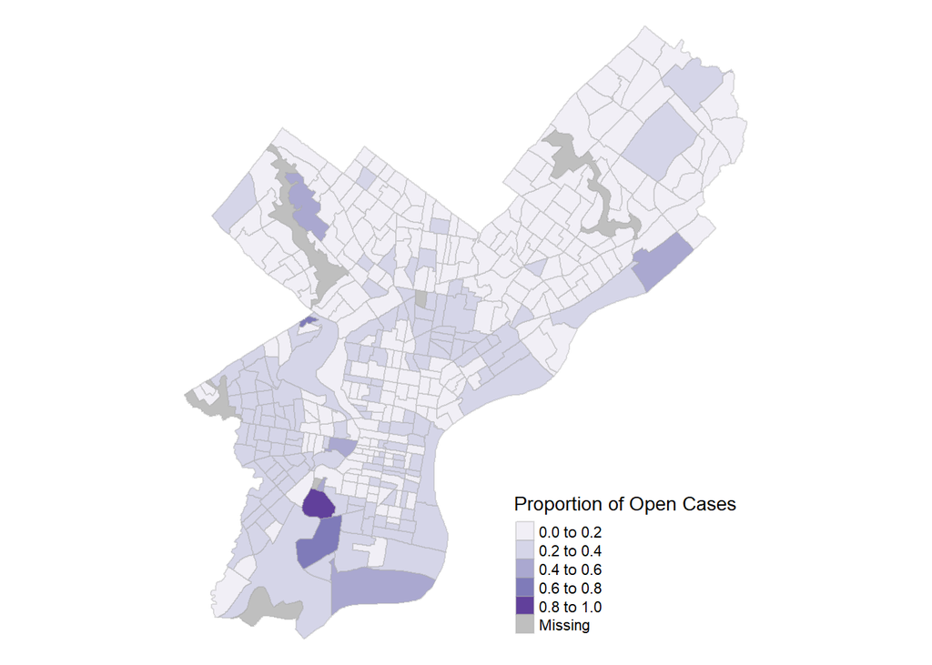

Proportion of ‘In Violation’ Cases by Tract- Philadelphia

```r
tm_shape(philly_tracts) +
  tm_fill(col = "in_violation", title = "Proportion of Open Cases", palette = "Purples") +
tm_borders(col = "gray67", alpha = .4) +
  tm_layout(frame = FALSE)
```